# ORG66BR2 3D Image-based Classification SVM analyses

# Information

The purpose of this screen was to develop an image-based classification to characterize dead or alive organoids in addition to standard CTG analyses  
We address organoid heterogeneity by creating an image-based signature for independent quantification of spheroids killed by cancer drugs.

The readouts from the high-content image analysis include morphology, intensity, and texture features of the spheroids in BF and Hoechst live-cell images.

## Conditions

- Alive/ healthy control (Vehicle control Wells from patient ORG66BR2)
- Dead organoids (high dose drug control Wells)
- Unknown phenotypes (all other Wells)

## Instrument

Cytation 10 (1 field @ 4X magnification)

## Compound Classes

The following classes (bins) were assigned to Wells averages in control Wells:

- **1. Controls with healthy/alive phenotype**
- **2. Controls with dead phenotype**
- **3. Unknown Wells** (all other Wells)

## Required R packages

tidyverse, e1071, plotly, rminer, matrixStats

```r
# load the required packages
library(e1071)
library(tidyverse)
library(platetools)
library(gridExtra)
library(ggpubr)
library(DT)
library(plotly)
library(knitr)
library(kableExtra)
library(reshape2)
library(caret)
# library(factoextra)
library(dendextend)
library(data.table)
# library(rminer)
library(matrixStats)
library(viridis)
library(here)

library(assertthat)
library(corrplot)
library(NbClust)
library(pheatmap)
library(RColorBrewer)
library(Rtsne)
library(writexl)
library(patchwork)



library(drc)
library(tidyr)
library(stringr)


# check if here() correctly identified the directory
here::here()
```

```
[1] "/Users/dalvinikita/Documents/7_GitHub/20241205_OC_ML_image_analyses_single_agents"
```

```r
# additional functions
source(here::here("code/heatmap_metadata.R"))

Mode <- function(x, na.rm = FALSE) {
    if (na.rm) {
        x = x[!is.na(x)]
    }

    ux <- unique(x)
    return(ux[which.max(tabulate(match(x, ux)))])
}


# fix facetted ggplotly axis labels (widw = long axis labels, narrow = short
# axis labels)
layout_ggplotly_wide <- function(gg, x = -0.06, y = -0.05) {
    # The 1 and 2 goes into the list that contains the options for the x and y
    # axis labels respectively
    gg[["x"]][["layout"]][["annotations"]][[1]][["y"]] <- x
    gg[["x"]][["layout"]][["annotations"]][[2]][["x"]] <- y
    gg
}

layout_ggplotly_narrow <- function(gg, x = -0.02, y = -0.055) {
    # The 1 and 2 goes into the list that contains the options for the x and y
    # axis labels respectively
    gg[["x"]][["layout"]][["annotations"]][[1]][["y"]] <- x
    gg[["x"]][["layout"]][["annotations"]][[2]][["x"]] <- y
    gg
}

# set the file prefix

prefix <- "OC_ORG66BR2"
patient <- "ORG66BR2"
```

# QC considerations

We used the Vehicle and Media wells as controls.

# Data processing

## Data annotation and import

Raw single organoid data was imported from CellProfiler outputs and CTG with annotations was imported from previous R outputs. The following Wells were excluded from Media and DMSO controls: H13-23, O13-23, N13-15, G13-15, I13-15, D14, K14, F3, M3.

*in addition to Staurosporine and Mitomycin, we added high dose Doxorubicin to the positive controls.*

```r
# per-image data
all_data_raw <- list.files(gsub(" ", "", paste(here::here("data/raw_data/staining/SingleOrganoid/"))),
    pattern = "*ORG66BR2.csv", full.names = T) %>%
    map_df(~fread(.)) %>%
    mutate(VCFG_Plate_ID = 1) %>%
    dplyr::select(VCFG_Plate_ID, Plate_ID = Metadata_Plate...7, Well_ID = Metadata_Well...11,
        ImageNumber, ObjectNumber, contains(c("AreaShape", "Intensity", "Texture",
            "Neighbors", "Spheroids", "RadialDistribution")))


annotationsCTG <- read_csv(here::here("data/OC_ORG66BR2_annotation_Dox.csv")) %>%
    dplyr::select(-WELL_ID)

# generate_heatmaps(annotationsCTG)

# annotationsCTG <- read_csv(here::here('data',
# 'OC_ORG66BR2_annotation_Dox.csv')) %>% left_join(annotationsCTG, by =
# c('Well_ID', 'VCFG_Plate_ID', 'Concentration', 'Units', 'Description',
# 'Compound_ID', 'Patient'))
```

Normalise CTG to media and DMSO controls.

```r
annotationsCTG <- read_csv(here::here("data/OC_ORG66BR2_annotation_Dox.csv"))

# calculate normalised values
norm_CTG <- annotationsCTG %>%
    filter(Compound_ID %in% c("Media", "DMSO")) %>%
    filter(!Well_ID %in% c("H13", "H14", "H15", "H16", "H17", "H18", "H19", "H20",
        "H21", "H22", "H23", "O13", "O14", "O15", "O16", "O17", "O18", "O19", "O20",
        "O21", "O22", "O23", "N13", "N14", "N15", "G13", "G14", "G15", "I13", "I14",
        "I15", "D14", "K14", "F3", "M3")) %>%
    group_by(Patient) %>%
    dplyr::summarise(neg_median = median(CTG)) %>%
    inner_join(annotationsCTG, ., by = c("Patient")) %>%
    mutate(CTG = CTG/neg_median) %>%
    dplyr::select(-neg_median) %>%
    filter(!Well_ID %in% c("H13", "H14", "H15", "H16", "H17", "H18", "H19", "H20",
        "H21", "H22", "H23", "O13", "O14", "O15", "O16", "O17", "O18", "O19", "O20",
        "O21", "O22", "O23", "N13", "N14", "N15", "G13", "G14", "G15", "I13", "I14",
        "I15", "D14", "K14", "F3", "M3"))
```

Bins were added to positive, negative, and library wells.

```r
all_data_with_bins <- all_data_raw %>%
    filter(!Well_ID %in% c("H13", "H14", "H15", "H16", "H17", "H18", "H19", "H20",
        "H21", "H22", "H23", "O13", "O14", "O15", "O16", "O17", "O18", "O19", "O20",
        "O21", "O22", "O23", "N13", "N14", "N15", "G13", "G14", "G15", "I13", "I14",
        "I15", "D14", "K14", "F3", "M3")) %>%
    left_join(., norm_CTG, by = c("Well_ID")) %>%
    na.omit()

# Now join this back to the original data and create the Bin column
all_data_with_bins <- all_data_with_bins %>%
    mutate(Bin = case_when(Description %in% c("negative_control") ~ "negative_control",
        Description %in% c("positive_control") ~ "positive_control", TRUE ~ "Sample")) %>%
    dplyr::select(Bin, Plate_ID, Replicate, ObjectNumber, WELL_ID, Concentration,
        Units, Description, Compound_ID, Patient, CTG, contains(c("AreaShape", "Intensity",
            "Texture", "Location", "Neighbors", "Spheroids", "RadialDistribution")))
# filter(AreaShape_Area >= 2000)




write.csv(all_data_with_bins, here::here("output/", patient, "/all_data_with_bins.csv"))
```

## Data overview

Compare raw data of all dead and alive control Wells it the current Patient.

```r
plot <- all_data_with_bins %>%
    filter(!AreaShape_Area < 1000) %>%
    filter(Bin %in% c("negative_control", "positive_control")) %>%
    ggplot(., aes(y = AreaShape_Area, x = as.factor(Bin), group = Patient)) + geom_point(aes(colour = as.factor(Bin)),
    alpha = 0.5, position = position_jitter(width = 0.2, height = 0.2)) + theme(axis.text.x = element_text()) +
    labs(title = "Spheroid Area", y = "raw area per single organoid (px2)", x = "Patient") +
    theme(legend.position = "none", axis.text.x = element_text(angle = 45, colour = "black",
        hjust = 1), axis.title.y = element_text(margin = margin(t = 0, r = 10, b = 0,
        l = 10)), axis.title.x = element_blank(), plot.title = element_text(margin = margin(t = 10,
        r = 0, b = 5, l = 0), size = 14), plot.subtitle = element_text(margin = margin(t = 0,
        r = 0, b = 10, l = 0), size = 6), strip.text.x = element_text(size = 8))



plot2 <- all_data_with_bins %>%
    filter(!AreaShape_Area < 1000) %>%
    filter(Bin %in% c("negative_control", "positive_control")) %>%
    ggplot(., aes(y = RadialDistribution_MeanFrac_CropBF_4of4, x = as.factor(Bin),
        group = Patient)) + geom_point(aes(colour = as.factor(Bin)), alpha = 0.5,
    position = position_jitter(width = 0.2, height = 0.2)) + theme(axis.text.x = element_text()) +
    labs(title = "BF Radial Distribution", y = "raw BF Radial Distrib single organoid",
        x = "Patient") + theme(legend.position = "none", axis.text.x = element_text(angle = 45,
    colour = "black", hjust = 1), axis.title.y = element_text(margin = margin(t = 0,
    r = 10, b = 0, l = 10)), axis.title.x = element_blank(), plot.title = element_text(margin = margin(t = 10,
    r = 0, b = 5, l = 0), size = 14), plot.subtitle = element_text(margin = margin(t = 0,
    r = 0, b = 10, l = 0), size = 6), strip.text.x = element_text(size = 8))



plot3 <- all_data_with_bins %>%
    filter(!AreaShape_Area < 1000) %>%
    filter(Bin %in% c("negative_control", "positive_control")) %>%
    ggplot(., aes(y = log2(CTG), x = as.factor(Bin), group = Patient)) + geom_point(aes(colour = as.factor(Bin)),
    alpha = 0.5, position = position_jitter(width = 0.2, height = 0.2)) + theme(axis.text.x = element_text()) +
    labs(title = "CTG raw", y = "raw CTG (log2) per WELL_ID", x = "Patient") + theme(legend.position = "none",
    axis.text.x = element_text(angle = 45, colour = "black", hjust = 1), axis.title.y = element_text(margin = margin(t = 0,
        r = 10, b = 0, l = 10)), axis.title.x = element_blank(), plot.title = element_text(margin = margin(t = 10,
        r = 0, b = 5, l = 0), size = 14), plot.subtitle = element_text(margin = margin(t = 0,
        r = 0, b = 10, l = 0), size = 6), strip.text.x = element_text(size = 8))


plot
```

[figure not shown]

```r
plot2
```

[figure not shown]

```r
plot3
```

[figure not shown]

```r
# plot plotly::ggplotly(plot, tooltip = c('Cell_Line', 'Count_Spheroids'))

rm(plot, plot2, plot3)
```

Area measurements of healthy organoids

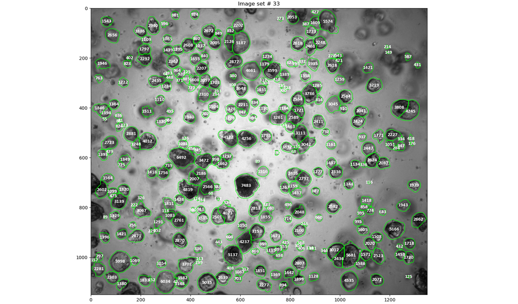

Area measurements of dead organoids

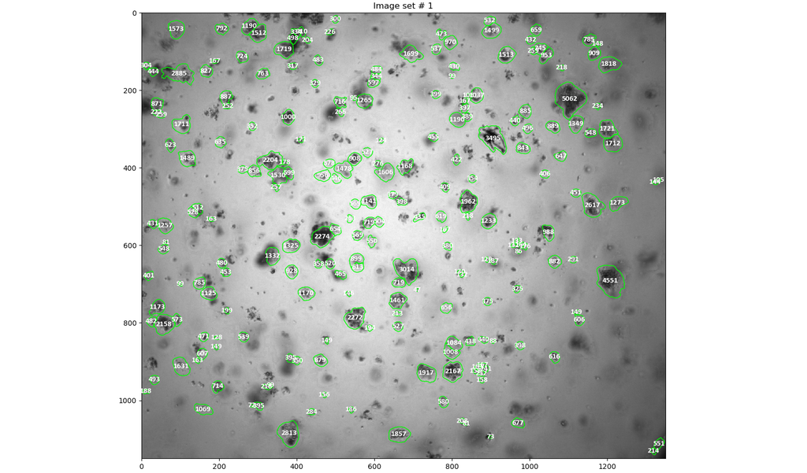

```r
# Filter and process data
data_with_medians <- all_data_with_bins %>%
    filter(Bin %in% c("negative_control", "positive_control")) %>%
    group_by(Bin) %>%
    summarize(Median = median(AreaShape_Area, na.rm = TRUE)) %>%
    ungroup()

# Histogram with density overlay
histogram_plot <- all_data_with_bins %>%
    filter(Bin %in% c("negative_control", "positive_control")) %>%
    ggplot(aes(x = AreaShape_Area, fill = Bin, color = Bin)) + geom_histogram(aes(y = ..density..),
    bins = 100, alpha = 0.4, position = "identity") + geom_density(alpha = 0.6) +
    xlim(0, 6000) + geom_vline(data = data_with_medians, aes(xintercept = Median,
    color = Bin), linetype = "dashed", size = 0.8) + labs(title = "Spheroid Area Distribution by Bin - all sizes",
    x = "Spheroid Area (px²)", y = "Density") + theme_minimal() + theme(legend.position = "top",
    axis.text.x = element_text(angle = 0, hjust = 0.5), plot.title = element_text(size = 14,
        face = "bold"))

# Display the histogram
print(histogram_plot)
```

[figure not shown]

```r
# Display the median values
print(data_with_medians)
```

```
# A tibble: 2 × 2
  Bin              Median
  <chr>             <dbl>
1 negative_control   1133
2 positive_control    566
```

**Filter out tiny organoids (<1000 in Area) because they are in all wells and bias the single organoid classification of the negative controls.**

```r
# Filter and process data
data_with_medians <- all_data_with_bins %>%
    filter(Bin %in% c("negative_control", "positive_control")) %>%
    filter(!AreaShape_Area < 1000) %>%
    group_by(Bin) %>%
    summarize(Median = median(AreaShape_Area, na.rm = TRUE)) %>%
    ungroup()

# Histogram with density overlay
histogram_plot <- all_data_with_bins %>%
    filter(!AreaShape_Area < 1000) %>%
    filter(Bin %in% c("negative_control", "positive_control")) %>%
    ggplot(aes(x = AreaShape_Area, fill = Bin, color = Bin)) + geom_histogram(aes(y = ..density..),
    bins = 100, alpha = 0.4, position = "identity") + geom_density(alpha = 0.6) +
    xlim(0, 6000) + geom_vline(data = data_with_medians, aes(xintercept = Median,
    color = Bin), linetype = "dashed", size = 0.8) + labs(title = "Spheroid Area Distribution by Bin (small ones exluded)",
    x = "Spheroid Area (px²)", y = "Density") + theme_minimal() + theme(legend.position = "top",
    axis.text.x = element_text(angle = 0, hjust = 0.5), plot.title = element_text(size = 14,
        face = "bold"))

# Display the histogram
print(histogram_plot)
```

[figure not shown]

```r
# Display the median values
print(data_with_medians)
```

```
# A tibble: 2 × 2
  Bin              Median
  <chr>             <dbl>
1 negative_control   1935
2 positive_control   1367
```

## Feature cleanup

### Remove NA, NaNs, Inf and others

```r
# First, create a function that checks if a column contains NA, NaN, or Inf
# values
check_column <- function(column) {
    any(is.na(column)) || any(is.nan(column)) || any(is.infinite(column))
}

# Next, create a list of the column names in the data frame
column_names <- names(all_data_with_bins)

# Loop through the column names and check if the corresponding column should be
# removed
to_remove <- c()
for (column_name in column_names[13:length(column_names)]) {
    column <- all_data_with_bins[[column_name]]
    if (check_column(column) || is.character(column) || all(column %in% c(0, -1)) ||
        any(grepl("Execution|Align|Height|Group_|ImageNumber|EulerNumber|_Center_|Scaling|Threshold|Width|Channel|Location",
            column_name))) {
        to_remove <- c(to_remove, column_name)
    }
}

# Remove the columns that should be removed
all_data_clean <- all_data_with_bins %>%
    dplyr::select(-to_remove) %>%
    filter(!AreaShape_Area < 1000)

clean_features <- names(all_data_clean[, -c(1:13)])
write.csv(all_data_clean, here::here("output/", patient, "/all_data_clean.csv"))

write.csv(all_data_clean, here::here("output/", patient, "/Feature_reduced_raw_data.csv"))
```

Of the total feature count of 214 there were 15 removed during feature clean-up

### Remove highly correlated features

All features with a Pearson’s correlation > 0.9 were removed.

```r
# Remove highly correlated features
raw2 <- all_data_clean
x <- raw2[, 13:ncol(raw2)]
x2 <- data.frame(lapply(x, as.numeric))
x3 <- x2[!sapply(x2, function(x) any(is.na(x)))]
y <- raw2[, 1:12]
all_features <- colnames(x3)

# make correlation_threshold function
correlation_threshold <- function(variables, sample, cutoff = 0.9, method = "pearson") {
    excluded_indexes <- sample %>%
        dplyr::select(.dots = variables) %>%
        cor(method = method) %>%
        caret::findCorrelation(cutoff = cutoff)

    variables[excluded_indexes]
}

CorData <- correlation_threshold(all_features, x3)
Cleaned <- x3[!(names(x3) %in% CorData)]
CleanedAn <- bind_cols(y, Cleaned)
cleaned_features <- colnames(Cleaned)


data_all_short <- CleanedAn

# remove all Samples (bin 3) and only keep the controls for classification
control_short <- data_all_short %>%
    filter(!Bin == "Sample")

write.csv(data_all_short, here::here(paste0("output/", patient, "/data_all_short.csv")))
```

There were 78 feature left after feature exclusion.

```r
# prepare the data frame back to long

raw2 <- CleanedAn %>%
    data.frame()

id <- colnames(raw2[c(1:10)])

features <- colnames(raw2[, 11:ncol(raw2)])

CleanedAn_melt <- raw2 %>%
    reshape2::melt(id.vars = id, measure.vars = features)
```

### Download feature reduced, raw data set

Download the raw data set used for Training and Testing of the SVM model from PRIME (“Feature_reduced_raw_data.csv”).

## Feature correlation

A correlation matrix was generated to investigate the relationship between each pair of features after feature reduction. A useful application of this plot may be to see which features are correlated with changes in cell area.

```r
# use only numerical data for correlation matrix
melt_cor1 <- data_all_short %>%
    dplyr::select(-c(1:11))

# generate correlation matrix
dat.cor = cor(melt_cor1, method = c("pearson"))

# str(melt_cor1)

# plot
corrplot(dat.cor, tl.col = "black", order = "hclust", hclust.method = "complete",
    tl.cex = 0.45)
```

[figure not shown]

```r
# save the plot as a PDF pdf(gsub(' ', '', paste('output/SVM_plots/', 'PN_SVM',
# '_Feature_Correlation', '.pdf')), width = 7, height = 7) corrplot(dat.cor,
# tl.col = 'black', order = 'hclust', hclust.method = 'complete', tl.cex = 0.5)
# dev.off()
```

# Train the SVM model

## Split data into training and test data set

80% of the controls are used for training, the remaining 20% of data points will be used to test the SVM algorithm.  
Now we make a data frame of the data, turning Bin (category 1 or 2) into a factor variable.

```r
dat2 <- control_short %>%
    as.data.frame() %>%
    dplyr::select(-c(2:11))
dat2[, 1] <- as.factor(dat2[, 1])  # Convert Bin to a factor


n <- nrow(dat2)  # Number of observations
ntrain <- round(n * 0.8)  # 80% for training set
set.seed(662)  # Set seed for reproducible results
tindex <- sample(n, ntrain)  # Create a random index
train_dat2 <- dat2[tindex, ]  # Create training set
test_dat2 <- dat2[-tindex, ]  # Create test set
```

## Centering and Scaling

Below, 80% of the data are used to estimate the location and scale of the predictors. The function *preProcess* doesn’t actually pre-process the data.  
*predict.preProcess* is used to pre-process this and other data sets (e.g. test set and validation set).

```r
preProcValues <- preProcess(train_dat2, method = c("center", "scale"))

trainTransformed <- predict(preProcValues, train_dat2)
testTransformed <- predict(preProcValues, test_dat2)
```

## Training without tuning

After that, we make a call to svm on this data frame, using Bin as the response variable and other variables as the predictors. The data frame will have unpacked the matrix x into 2 columns named negative_control and positive_control.

```r
svmfit2 = svm(Bin ~ ., data = trainTransformed, kernel = "radial", probability = TRUE)

summary(svmfit2)
```

```
Call:
svm(formula = Bin ~ ., data = trainTransformed, kernel = "radial",
    probability = TRUE)


Parameters:
   SVM-Type:  C-classification
 SVM-Kernel:  radial
       cost:  1

Number of Support Vectors:  1390

 ( 649 741 )


Number of Classes:  2

Levels:
 negative_control positive_control
```

```r
# Number of columns in the data frame, excluding the response variable
num_features <- ncol(trainTransformed) - 1

# Calculate default gamma
default_gamma <- 1/num_features

default_gamma
```

```
[1] 0.01265823
```

We tell SVM that the kernel is **radial**, the tune-in parameter cost is 1 and the gamma is 0.0126582.

## Prediction and Confusion Matrix

### True labels

Here is the result of the prediction of the training set, comparing the result of SVM “Prediction” and the class data provided by us in Bin variable as “Reference”.

```r
pred <- predict(svmfit2, trainTransformed, probability = TRUE)
# system.time(pred <- predict(svmfit2,trainTransformed))

cf <- confusionMatrix(pred, trainTransformed$Bin)
cf
```

```
Confusion Matrix and Statistics

                  Reference
Prediction         negative_control positive_control
  negative_control             4720              128
  positive_control               70             1272

               Accuracy : 0.968
                 95% CI : (0.9633, 0.9723)
    No Information Rate : 0.7738
    P-Value [Acc > NIR] : < 2.2e-16

                  Kappa : 0.9073

 Mcnemar's Test P-Value : 5.104e-05

            Sensitivity : 0.9854
            Specificity : 0.9086
         Pos Pred Value : 0.9736
         Neg Pred Value : 0.9478
             Prevalence : 0.7738
         Detection Rate : 0.7625
   Detection Prevalence : 0.7832
      Balanced Accuracy : 0.9470

       'Positive' Class : negative_control
```

```r
fourfoldplot(as.table(cf), color = c("yellow", "pink"), main = "Confusion Matrix")
```

[figure not shown]

### Scrambled category labels

```r
trainTransformed_scr <- transform(trainTransformed, Bin = sample(Bin))
```

By randomising/scrambling the category labels, we create a data set that should not be predicted correctly and indeed, the prediction accuracy for the scrambled data drops down to 66%.

```r
pred_scr <- predict(svmfit2, trainTransformed_scr, probability = TRUE)

cf <- confusionMatrix(pred_scr, trainTransformed_scr$Bin)
cf
```

```
Confusion Matrix and Statistics

                  Reference
Prediction         negative_control positive_control
  negative_control             3752             1096
  positive_control             1038              304

               Accuracy : 0.6553
                 95% CI : (0.6433, 0.6671)
    No Information Rate : 0.7738
    P-Value [Acc > NIR] : 1.0000

                  Kappa : 4e-04

 Mcnemar's Test P-Value : 0.2172

            Sensitivity : 0.7833
            Specificity : 0.2171
         Pos Pred Value : 0.7739
         Neg Pred Value : 0.2265
             Prevalence : 0.7738
         Detection Rate : 0.6061
   Detection Prevalence : 0.7832
      Balanced Accuracy : 0.5002

       'Positive' Class : negative_control
```

```r
fourfoldplot(as.table(cf), color = c("yellow", "pink"), main = "Confusion Matrix")
```

[figure not shown]

# Tuning SVM

The kernel argument has a variety of possible types including linear, polynomial, radial, and sigmoid. We use kernel=”radial” for this classification problem. You can tune the operation of svm() with two additional arguments: gamma and cost, where gamma is the argument for use by the kernel function, and cost allows us to specify the cost of a violation to the margin. When cost is small, the margins will be wide, resulting in many support vectors. You can experiment with different values of gamma and cost to find the best classification accuracy.

```r
# Define new values for gamma and cost
new_gamma <- 0.01
new_cost <- 5

# Create the SVM model with the new gamma and cost values
svm_model_after_tune = svm(Bin ~ ., data = trainTransformed, kernel = "radial", gamma = new_gamma,
    cost = new_cost, probability = TRUE)

summary(svm_model_after_tune)
```

```
Call:
svm(formula = Bin ~ ., data = trainTransformed, kernel = "radial",
    gamma = new_gamma, cost = new_cost, probability = TRUE)


Parameters:
   SVM-Type:  C-classification
 SVM-Kernel:  radial
       cost:  5

Number of Support Vectors:  1256

 ( 568 688 )


Number of Classes:  2

Levels:
 negative_control positive_control
```

```r
save(svm_model_after_tune, file = here::here("output/", patient, "svm_model_after_tune.RData"))
```

```r
load(here::here("output/", patient, "svm_model_after_tune.RData"))
```

```r
# svm_tune <- tune(svm, Bin~., data = trainTransformed, kernel='radial',
# ranges=list(cost=10^(-2:3), gamma=c(.00001, .001,.01,.1,.5,1)) )

# save(svm_tune, file = here::here('output/svm_tune.RData'))
# load(here::here('output/svm_tune.RData'))

# print(svm_tune) print(svm_tune$performances) performances <-
# svm_tune$performances plot(performances)
```

## Prediction and Confusion Matrix with new model

```r
pred2 <- predict(svm_model_after_tune, trainTransformed, probability = TRUE)

cf <- confusionMatrix(pred2, trainTransformed$Bin)
cf
```

```
Confusion Matrix and Statistics

                  Reference
Prediction         negative_control positive_control
  negative_control             4768               51
  positive_control               22             1349

               Accuracy : 0.9882
                 95% CI : (0.9852, 0.9907)
    No Information Rate : 0.7738
    P-Value [Acc > NIR] : < 2.2e-16

                  Kappa : 0.9661

 Mcnemar's Test P-Value : 0.001049

            Sensitivity : 0.9954
            Specificity : 0.9636
         Pos Pred Value : 0.9894
         Neg Pred Value : 0.9840
             Prevalence : 0.7738
         Detection Rate : 0.7703
   Detection Prevalence : 0.7785
      Balanced Accuracy : 0.9795

       'Positive' Class : negative_control
```

```r
fourfoldplot(as.table(cf), color = c("yellow", "pink"), main = "Confusion Matrix")
```

[figure not shown]

# Plot Model Characteristics

## Decision Values

### True labels

You can also learn something when you display the Decision Values (DV) calculated by SVM using the svmfit2$DV component of the fitted model, versus the assigned Category labels.

```r
DV <- svm_model_after_tune$decision.values

prob <- attr(pred, "probabilities")
plot(trainTransformed$Bin, DV, ylab = "DV", xlab = "Category")
```

[figure not shown]

```r
# plot(SV[,1], SV[,2])

# plot(prob, pch = 19, ylab='probability of category 2', xlab='probability of
# category 1')

# bind probabilities and Bin labels together
trainTransformed_x <- trainTransformed %>%
    mutate(id = row_number())
prob_x <- prob %>%
    data.frame() %>%
    mutate(id = row_number())


trainTransformed_prob <- left_join(prob_x, trainTransformed_x, by = c("id")) %>%
    dplyr::mutate(prob_alive = negative_control, prob_dead = positive_control, true_labels = Bin) %>%
    dplyr::select(-c(negative_control, positive_control, id))

plot2 <- trainTransformed_prob %>%
    ggplot(., aes(y = prob_alive, x = true_labels, group = true_labels)) + geom_point(aes(colour = true_labels),
    alpha = 0.5, position = position_jitter(width = 0.2, height = 0.2)) + theme(axis.text.x = element_text()) +
    labs(title = "True labels vs Probabilities", y = "Probability of being categorised as cystic",
        x = "true labels") + geom_hline(aes(yintercept = 0.5), linetype = "solid",
    color = "black") + theme(legend.title = element_text(), legend.text = element_blank(),
    axis.text.x = element_text(angle = 25, colour = "black"), axis.title.y = element_text(margin = margin(t = 0,
        r = 30, b = 0, l = 30)), axis.title.x = element_text(margin = margin(t = 10,
        r = 0, b = 30, l = 0)), plot.title = element_text(margin = margin(t = 10,
        r = 0, b = 5, l = 0), size = 14), plot.subtitle = element_text(margin = margin(t = 0,
        r = 0, b = 10, l = 0), size = 6), strip.text.x = element_text(size = 8))


plot2
```

[figure not shown]

```r
# plotly::ggplotly(plot2, tooltip = c('prob_alive', 'true_labels'))


# save the plot as a PDF pdf(gsub(' ', '', paste('output/SVM_plots/', 'PN_SVM',
# '_DV_after_tuning', '.pdf')), width = 3, height = 3)
# plot(trainTransformed$Bin, DV, ylab='DV', xlab='Category') dev.off()
```

### Scrambled labels

```r
DV <- svm_model_after_tune$decision.values

prob_scr <- attr(pred_scr, "probabilities")
plot(trainTransformed_scr$Bin, DV, ylab = "DV", xlab = "Category")
```

[figure not shown]

```r
# plot(SV[,1], SV[,2])

# plot(prob_scr, pch = 19, ylab='probability of category 2', xlab='probability
# of category 1')


# bind probabilities and Bin labels together
trainTransformed_scr_x <- trainTransformed_scr %>%
    mutate(id = row_number())
prob_scr_x <- prob_scr %>%
    data.frame() %>%
    mutate(id = row_number())
# names(pred_x)[1] <- 'pred_tox'

trainTransformed_prob <- left_join(prob_scr_x, trainTransformed_scr_x, by = c("id")) %>%
    dplyr::mutate(prob_alive = negative_control, prob_dead = positive_control, scrambled_labels = Bin) %>%
    dplyr::select(-c(negative_control, positive_control, id))

plot2 <- trainTransformed_prob %>%
    ggplot(., aes(y = prob_alive, x = scrambled_labels, group = scrambled_labels)) +
    geom_point(aes(colour = scrambled_labels), alpha = 0.5, position = position_jitter(width = 0.2,
        height = 0.2)) + theme(axis.text.x = element_text()) + labs(title = "Scrambled labels vs Probabilities",
    y = "Probability of being categorised as cystic", x = "scrambled labels") + geom_hline(aes(yintercept = 0.5),
    linetype = "solid", color = "black") + theme(legend.title = element_text(), legend.text = element_blank(),
    axis.text.x = element_text(angle = 25, colour = "black"), axis.title.y = element_text(margin = margin(t = 0,
        r = 30, b = 0, l = 30)), axis.title.x = element_text(margin = margin(t = 10,
        r = 0, b = 30, l = 0)), plot.title = element_text(margin = margin(t = 10,
        r = 0, b = 5, l = 0), size = 14), plot.subtitle = element_text(margin = margin(t = 0,
        r = 0, b = 10, l = 0), size = 6), strip.text.x = element_text(size = 8))




plot2
```

[figure not shown]

```r
# plotly::ggplotly(plot2, tooltip = c('prob_alive', 'scrambled_labels'))



# save the plot as a PDF pdf(gsub(' ', '', paste('output/SVM_plots/', 'PN_SVM',
# '_DV_after_label_randomisation', '.pdf')), width = 3, height = 3)
# plot(trainTransformed_scr$Bin, DV, ylab='DV', xlab='Category') dev.off()
```

## Contributions of the variables to the model performance

This list ranks the Importance values of each imaging feature regarding their contribution to the model performance.

```r
w <- t(svm_model_after_tune$coefs) %*% svm_model_after_tune$SV  # weight vectors
w <- apply(w, 2, function(v) {
    sqrt(sum(v^2))
})  # weight
w <- sort(w, decreasing = T) %>%
    data.frame()
w <- setDT(w, keep.rownames = TRUE)[]
colnames(w) <- c("Feature", "Importance")

datatable(w, extensions = c("Buttons", "Scroller"), rownames = FALSE, options = list(dom = "Blrt",
    lengthMenu = list(c(10, 30), c("10", "30")), pageLength = 10, buttons = list(list(extend = "csv",
        filename = "IMP_Names"), list(extend = "excel", filename = "IMP_Names", title = "IMP_Names")),
    searching = FALSE, scrollX = TRUE))
```

| Feature | Importance |
| --- | --- |
| Intensity_StdIntensityEdge_CropDAPI | 126.8018399508293 |
| Intensity_MaxIntensityEdge_CropBF | 111.0832111450033 |
| Intensity_MaxIntensityEdge_CropDAPI | 95.80170175326307 |
| Texture_AngularSecondMoment_CropDAPI_3_03_256 | 95.4697583423084 |
| Texture_InverseDifferenceMoment_CropDAPI_3_01_256 | 94.93254637294837 |
| RadialDistribution_RadialCV_CropDAPI_4of4 | 90.38081351563675 |
| Texture_DifferenceVariance_CropDAPI_3_01_256 | 88.70414571630405 |
| Texture_InfoMeas1_CropDAPI_3_00_256 | 81.77241202668039 |
| Texture_SumAverage_CropBF_3_01_256 | 81.05660638571341 |
| Intensity_MaxIntensity_CropDAPI | 63.91411786535799 |

[output cut: 69 more lines]

# Testing

Now we can use the predict() function with the trained SVM model to make predictions using the test set. The result is delivered as a factor variable containing the predicted classes for each observation in the test set. Next, we can use the confusionMatrix() function to create a “confusion matrix” for checking the accuracy of the model.

## Testing with correct labels

Testing the SVM model on the last 20% of data gives a 94% accuracy in prediction.

```r
prediction <- predict(svm_model_after_tune, testTransformed, probability = TRUE)

cf <- confusionMatrix(prediction, testTransformed$Bin)
cf
```

```
Confusion Matrix and Statistics

                  Reference
Prediction         negative_control positive_control
  negative_control             1134               62
  positive_control               34              317

               Accuracy : 0.9379
                 95% CI : (0.9247, 0.9494)
    No Information Rate : 0.755
    P-Value [Acc > NIR] : < 2.2e-16

                  Kappa : 0.828

 Mcnemar's Test P-Value : 0.005857

            Sensitivity : 0.9709
            Specificity : 0.8364
         Pos Pred Value : 0.9482
         Neg Pred Value : 0.9031
             Prevalence : 0.7550
         Detection Rate : 0.7330
   Detection Prevalence : 0.7731
      Balanced Accuracy : 0.9037

       'Positive' Class : negative_control
```

```r
fourfoldplot(as.table(cf), color = c("yellow", "pink"), main = "Confusion Matrix")
```

[figure not shown]

## Testing with scrambled labels

Testing the SVM model on the last 20% of data after scrambling the category labels gives a random 64% accuracy in prediction.

```r
test_dat2_scr <- transform(testTransformed, Bin = sample(Bin))

prediction_scr <- predict(svm_model_after_tune, test_dat2_scr, probability = TRUE)

cf <- confusionMatrix(prediction_scr, test_dat2_scr$Bin)
cf
```

```
Confusion Matrix and Statistics

                  Reference
Prediction         negative_control positive_control
  negative_control              906              290
  positive_control              262               89

               Accuracy : 0.6432
                 95% CI : (0.6187, 0.6671)
    No Information Rate : 0.755
    P-Value [Acc > NIR] : 1.0000

                  Kappa : 0.0108

 Mcnemar's Test P-Value : 0.2505

            Sensitivity : 0.7757
            Specificity : 0.2348
         Pos Pred Value : 0.7575
         Neg Pred Value : 0.2536
             Prevalence : 0.7550
         Detection Rate : 0.5856
   Detection Prevalence : 0.7731
      Balanced Accuracy : 0.5053

       'Positive' Class : negative_control
```

```r
fourfoldplot(as.table(cf), color = c("yellow", "pink"), main = "Confusion Matrix")
```

[figure not shown]

# View how all organoids are categorised

Here is a table of all the conditions and a display of the pre-assigned category (1, 2, 3) and the probability of being alive (negative_control) or dead (positive_control).

The data is displayed as the original raw data (rather than the centred and scaled data format that was used to build the model).

```r
dat2 <- control_short %>%
    as.data.frame() %>%
    dplyr::select(-c(2:11))
dat2[, 1] <- as.factor(dat2[, 1])  # Convert Bin to a factor



data_all_short_all <- data_all_short %>%
    dplyr::select(Bin, everything())
write.csv(data_all_short_all, here::here(paste0("output/", patient, "/data_all_short_all1.csv")))

dat_V <- data_all_short_all %>%
    as.data.frame() %>%
    dplyr::select(-c(2:11))
dat_V[, 1] <- as.factor(dat_V[, 1])  # Convert Bin to a factor

LibTransformed <- predict(preProcValues, dat_V)  #centering and scaling


prediction <- predict(svm_model_after_tune, LibTransformed, probability = TRUE)
prob <- attr(prediction, "probabilities")

confusionMatrix(prediction, LibTransformed$Bin)
```

```
Confusion Matrix and Statistics

                  Reference
Prediction         negative_control positive_control Sample
  negative_control             5902              113  17508
  positive_control               56             1666   5192
  Sample                          0                0      0

Overall Statistics

               Accuracy : 0.2486
                 95% CI : (0.2438, 0.2535)
    No Information Rate : 0.7458
    P-Value [Acc > NIR] : 1

                  Kappa : 0.1006

 Mcnemar's Test P-Value : <2e-16

Statistics by Class:

                     Class: negative_control Class: positive_control
Sensitivity                           0.9906                 0.93648
Specificity                           0.2802                 0.81687
Pos Pred Value                        0.2509                 0.24096
Neg Pred Value                        0.9919                 0.99520
Prevalence                            0.1957                 0.05845
Detection Rate                        0.1939                 0.05474
Detection Prevalence                  0.7728                 0.22716
Balanced Accuracy                     0.6354                 0.87668
                     Class: Sample
Sensitivity                 0.0000
Specificity                 1.0000
Pos Pred Value                 NaN
Neg Pred Value              0.2542
Prevalence                  0.7458
Detection Rate              0.0000
Detection Prevalence        0.0000
Balanced Accuracy           0.5000
```

```r
summary = data.frame(data_all_short_all, as.numeric(levels(prediction))[prediction])
write.csv(summary, here::here(paste0("output/", patient, "/summary_morphology_ORG66BR2.csv")))
```

## All organoids

Link to download “pred_all_data.csv” from PRIME

```r
pred_all_data = data.frame(prob, data_all_short_all)

# Group by WELL_ID and count ObjectNumber rows
well_object_count <- data_all_short_all %>%
    group_by(WELL_ID, Description, Patient) %>%
    summarise(Object_count = n())

well_object_count_norm <- well_object_count %>%
    filter(Description %in% c("negative_control")) %>%
    group_by(Patient) %>%
    dplyr::summarise(neg_median = median(Object_count)) %>%
    inner_join(well_object_count, ., by = c("Patient")) %>%
    mutate(Object_count = Object_count/neg_median) %>%
    dplyr::select(-neg_median)


pred_all_data_norm <- pred_all_data %>%
    dplyr::select(WELL_ID, Description, Patient, AreaShape_Area) %>%
    filter(Description %in% c("negative_control")) %>%
    group_by(Patient) %>%
    dplyr::summarise(neg_median = median(AreaShape_Area)) %>%
    inner_join(pred_all_data, ., by = c("Patient")) %>%
    mutate(AreaShape_Area = AreaShape_Area/neg_median) %>%
    dplyr::select(WELL_ID, Description, Patient, AreaShape_Area) %>%
    group_by(WELL_ID, Patient) %>%
    dplyr::summarise(AreaShape_Area = median(AreaShape_Area))


pred_all_data_mean <- pred_all_data %>%
    ungroup() %>%
    dplyr::select(-AreaShape_Area) %>%
    left_join(., pred_all_data_norm, by = c("WELL_ID", "Patient")) %>%
    dplyr::select(Plate_ID, Replicate, Patient, Description, Compound_ID, Concentration,
        WELL_ID, CTG, Bin, AreaShape_Area, negative_control, positive_control) %>%
    group_by(Plate_ID, WELL_ID, Patient, Description, Compound_ID, Concentration) %>%
    dplyr::mutate(prob_alive = mean(negative_control), prob_dead = mean(positive_control),
        Area = mean(AreaShape_Area)) %>%
    dplyr::select(-c(positive_control, negative_control, AreaShape_Area)) %>%
    unique() %>%
    mutate(across(where(is.numeric), ~round(.x, 2))) %>%
    ungroup()
write.csv(pred_all_data, here::here(paste0("output/", patient, "/pred_all_data_ORG66BR2.csv")))

# select_pred_all_data <- pred_all_data %>% filter(!Description == 'Empty' &
# Condition %in% c('3RR+F', '3R+LY'))




# datatable(pred_all_data, extensions = c('Buttons', 'Scroller'), rownames =
# FALSE, options = list( dom = 'Blrt', lengthMenu = list(c(10, 20), c('10',
# '20')), pageLength = 10, buttons = list(list(extend = 'csv', filename =
# 'prediction'), list(extend = 'excel', filename = 'prediction', title =
# 'prediction')), searching = TRUE, scrollX = TRUE ))

write.csv(pred_all_data, here::here("output/pred_all_data.csv"))
```

## Average predictions

Link to download and “pred_all_data_mean.csv”.

```r
datatable(pred_all_data_mean, extensions = c("Buttons", "Scroller"), rownames = FALSE,
    options = list(dom = "Blrt", lengthMenu = list(c(10, 30), c("10", "30")), pageLength = 10,
        buttons = list(list(extend = "csv", filename = "pred_all_data_mean"), list(extend = "excel",
            filename = "pred_all_data_mean", title = "pred_all_data_mean")), searching = FALSE,
        scrollX = TRUE))
```

| Plate_ID | Replicate | Patient | Description | Compound_ID | Concentration | WELL_ID | CTG | Bin | prob_alive | prob_dead | Area |
| --- | --- | --- | --- | --- | --- | --- | --- | --- | --- | --- | --- |
| ORG66BR2 | 2 | Org66 | positive_control | Staurosporine | 0.5 | B10 | 0.05 | positive_control | 0.14 | 0.86 | 0.79 |
| ORG66BR2 | 2 | Org66 | positive_control | Staurosporine | 0.2 | B11 | 0.26 | positive_control | 0.12 | 0.88 | 0.77 |
| ORG66BR2 | 2 | Org66 | Sample | Staurosporine | 0.1 | B12 | 0.63 | Sample | 0.46 | 0.54 | 0.79 |
| ORG66BR2 | 2 | Org66 | Sample | Carboplatin | 20 | B14 | 0.66 | Sample | 0.96 | 0.04 | 0.94 |
| ORG66BR2 | 2 | Org66 | Sample | Carboplatin | 10 | B15 | 0.96 | Sample | 0.96 | 0.04 | 0.87 |
| ORG66BR2 | 2 | Org66 | Sample | Carboplatin | 7.5 | B16 | 1.08 | Sample | 0.97 | 0.03 | 0.93 |
| ORG66BR2 | 2 | Org66 | Sample | Carboplatin | 5 | B17 | 1.22 | Sample | 0.98 | 0.02 | 0.99 |
| ORG66BR2 | 2 | Org66 | Sample | Carboplatin | 2 | B18 | 1.29 | Sample | 0.97 | 0.03 | 1.11 |
| ORG66BR2 | 2 | Org66 | Sample | Carboplatin | 1 | B19 | 1.21 | Sample | 0.97 | 0.03 | 1.02 |
| ORG66BR2 | 2 | Org66 | Sample | Carboplatin | 0.75 | B20 | 1.2 | Sample | 0.96 | 0.04 | 1.02 |

[output cut: 260 more lines]

```r
write.csv(pred_all_data_mean, here::here(paste0("output/", patient, "/pred_all_data_mean_ORG66BR2.csv")))
```

## Heat map

Plot the Patient average probability of the population being alive by Compound and Concentration.

```r
# create a unique ID column
data_heat <- pred_all_data_mean %>%
    unite(Batch, c(Plate_ID), sep = " - ", remove = FALSE)

plate_list <- unique(data_heat$Batch)

for (i in plate_list) {

    data_plot <- data_heat %>%
        filter(Batch == i)

    # calculate the min, median and max of the dataset in order to set the same
    # scale for all plates
    feature_vect <- data_plot$prob_alive

    med <- median(feature_vect)
    max <- max(feature_vect)
    min <- min(feature_vect)

    # make plots
    plots <- data_plot %>%
        dplyr::group_by(Batch) %>%
        dplyr::do(plots = platetools::raw_map(data = .$prob_alive, well = .$WELL_ID,
            plate = 384) + ggtitle(.$Batch[1]) + scale_fill_gradient2(low = "blue",
            mid = "white", high = "red", midpoint = med, limits = c(floor(min), ceiling(max))) +
            theme(plot.title = element_text(size = 22), axis.text.x = element_text(size = 4),
                axis.text.y = element_text(size = 4)))

    myplots <- list()
    for (i in 1:length(unique(data_plot$Batch))) {
        p1 <- eval(substitute(print(plots$plots[[i]]), list(i = i)))
        myplots[[i]] <- p1
    }

}
```

[figure not shown]

## Correlation CTG vs SVM probabilities

```r
library(purrr)

# Step 1: Compute R^2 for each patient
r2_by_patient <- pred_all_data_mean %>%
    group_by(Patient) %>%
    nest() %>%
    mutate(model = map(data, ~lm(prob_alive ~ CTG, data = .x)), summary_model = map(model,
        ~base::summary(.x)), r2 = map_dbl(summary_model, ~.$r.squared)) %>%
    dplyr::select(Patient, r2)

# Step 2: Make the plot and annotate with R^2 values for each facet
normplot1 <- pred_all_data_mean %>%
    ggplot(., aes(x = CTG, y = prob_alive, group = Patient)) + geom_point(aes(colour = Patient,
    text = paste("Compound_Name:", Compound_ID, "<br>CTG:", CTG, "<br>Concentration:",
        Concentration, "<br>ML classificaton:", prob_alive, "<br>Well_ID:", WELL_ID)),
    alpha = 0.8, size = 1.6) + geom_smooth(method = "lm", se = FALSE, color = "black",
    linetype = "dashed") + geom_text(data = r2_by_patient, aes(label = sprintf("R^2 = %.2f",
    r2), x = Inf, y = Inf), hjust = 1, vjust = 1, inherit.aes = FALSE, size = 5) +
    labs(title = "CTG Norm vs SVM probabilities \n", x = "CTG Raw", y = "Probability of being alive") +
    theme_bw() + theme(axis.title.x = element_text(margin = margin(t = 10, r = 10,
    b = 20, l = 20)), axis.title.y = element_text(margin = margin(t = 0, r = 10,
    b = 0, l = 20)), axis.text.x = element_text(angle = 0, colour = "black", size = 10,
    hjust = 1), axis.text.y = element_text(colour = "black", size = 10), strip.text = element_text(size = 11),
    plot.title = element_text(margin = margin(t = 10, r = 0, b = 5, l = 0), size = 14),
    plot.margin = margin(t = 0, r = 30, b = 0, l = 30), legend.position = "none")

print(normplot1)
```

[figure not shown]

```r
# plotly::ggplotly(normplot1, tooltip = c('text'))
```

## SVM-probabilities dose-response curves compared to CTG

```r
raw2 <- pred_all_data_mean %>%
    data.frame() %>%
    left_join(., well_object_count_norm, by = c("WELL_ID", "Patient", "Description"))

id <- colnames(raw2[c(1:7, 9)])

features <- colnames(raw2[c(8, 10, 12, 13)])

pred_all_data_melt <- raw2 %>%
    reshape2::melt(id.vars = id, measure.vars = features)


data_norm_plot <- pred_all_data_melt %>%
    filter(!Concentration == 0) %>%
    group_by(Compound_ID, Plate_ID, Patient, Concentration, variable) %>%
    summarise_at(vars(value), funs(mean, sd))

normplot <- data_norm_plot %>%
    unite("Identifyer", c(Plate_ID, Patient), sep = "_", remove = FALSE) %>%
    ggplot(., aes(x = Concentration, y = mean, group = variable)) + geom_point(aes(colour = variable),
    alpha = 0.8, size = 1.6) + geom_errorbar(aes(ymin = mean - sd, ymax = mean +
    sd), width = 0.2, size = 0.2) + geom_line(aes(colour = variable), alpha = 0.8,
    size = 0.8) + geom_hline(aes(yintercept = 1), linetype = "solid", size = 0.2) +
    facet_wrap(~Compound_ID, ncol = 3) + scale_x_continuous(trans = "log10", labels = scales::number_format(accuracy = 0.1)) +
    labs(title = "SVM results ORG66BR2\n", x = "Log10 Concentration (uM)", y = "Probability of being alive") +
    theme_bw() + theme(axis.title.x = element_text(margin = margin(t = 10, r = 10,
    b = 20, l = 20)), axis.title.y = element_text(margin = margin(t = 0, r = 10,
    b = 0, l = 20)), axis.text.x = element_text(angle = 25, colour = "black", size = 10,
    hjust = 1), axis.text.y = element_text(colour = "black", size = 10), strip.text = element_text(size = 12),
    plot.title = element_text(margin = margin(t = 10, r = 0, b = 5, l = 0), size = 14),
    plot.margin = margin(t = 0, r = 30, b = 0, l = 30))

normplot
```

[figure not shown]

## Single organoid results

```r
# avoid the use of scientific notation
options(scipen=999)


p1 <- pred_all_data %>%
  filter(!Concentration ==0) %>%
  ggplot(., aes(x = as.factor(Concentration), y = negative_control, fill = Compound_ID)) +  # Converted Concentration to factor for discrete x-axis
  geom_violin(width = 0.8, alpha = 1) +  # Violin plot
  geom_hline(aes(yintercept = 0.50), linetype = "solid") +  # Horizontal line
  labs(
    title = "Dose-Response of Single Organoids",
    y = "Response (Probability of being categorised as alive)",
    x = "Concentration (uM)"
  ) +
  facet_wrap(~Compound_ID, ncol = 3) +
  theme(
    legend.title = element_text(),
    legend.text = element_blank(),
    axis.text.x = element_text(angle = 90, colour = "black", size = 8),
    axis.title.y = element_text(margin = margin(t = 0, r = 10, b = 0, l = 10)),
    axis.title.x = element_text(margin = margin(t = 10, r = 10, b = 20, l = 20)),
    plot.title = element_text(margin = margin(t = 10, r = 0, b = 5, l = 0), size = 14),
    strip.text.x = element_text(size = 14),
    legend.position = "none"
  )

print(p1)
```

[figure not shown]

Analysed by Susanne Ramm

*Susanne.Ramm@petermac.org*

[Victorian Centre for Functional Genomics](https://www.petermac.org/research/core-facilities/victorian-centre-functional-genomics)